# 03-Deep Neural Network

## Introduction

The goal of this notebook is to illustrate why neural networks—and in particular deep neural networks—are effective for learning non-linear decision boundaries, using a controlled, side-by-side comparison.

We study a simple two-dimensional classification problem with non-linear structure and compare three models of increasing representational capacity: 1. Logistic Regression, representing a linear decision boundary 2. A shallow neural network with a single hidden layer 3. A deep neural network with multiple hidden layers

The comparison focuses on:

```
•	learning dynamics (accuracy over epochs),
•	final predictive performance (accuracy, AUC, log loss), and
•	the geometry of learned decision boundaries.
```

Rather than optimizing for maximum performance, the emphasis is on interpretability and understanding: how increasing depth changes what the model can represent, how quickly it learns, and how its decision boundary adapts to non-linear data.

## 1. Generate Non-Linear Data + Visualization

```python
import numpy as np
import pandas as pd
import matplotlib.pyplot as plt

from sklearn.datasets import make_moons, make_circles
from sklearn.model_selection import train_test_split
from sklearn.preprocessing import StandardScaler
from sklearn.metrics import accuracy_score, log_loss, roc_auc_score, confusion_matrix

import torch
import torch.nn as nn
from torch.utils.data import TensorDataset, DataLoader

SEED = 42
np.random.seed(SEED)
torch.manual_seed(SEED)
torch.set_float32_matmul_precision("high")  # optional
```

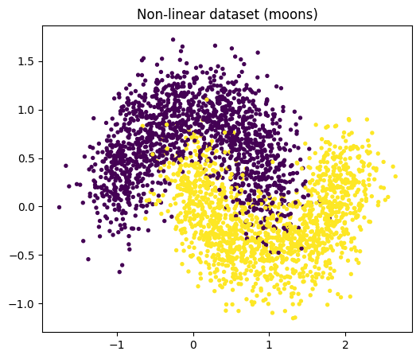

```python
def make_data(kind="moons", n_samples=3000, noise=0.25):
    if kind == "moons":
        X, y = make_moons(n_samples=n_samples, noise=noise, random_state=SEED)
    elif kind == "circles":
        X, y = make_circles(n_samples=n_samples, noise=noise, factor=0.5, random_state=SEED)
    else:
        raise ValueError("kind must be 'moons' or 'circles'")
    return X.astype(np.float32), y.astype(np.int64)

X, y = make_data(kind="moons", n_samples=3000, noise=0.25)

plt.figure(figsize=(6,5))
plt.scatter(X[:,0], X[:,1], c=y, s=8)
plt.title("Non-linear dataset (moons)")
plt.show()
```

## 2. Train/Test Split + Standardization

```python
X_train, X_test, y_train, y_test = train_test_split(
    X, y, test_size=0.25, random_state=SEED, stratify=y
)

scaler = StandardScaler()
X_train_s = scaler.fit_transform(X_train).astype(np.float32)
X_test_s  = scaler.transform(X_test).astype(np.float32)

# Torch tensors
Xtr = torch.tensor(X_train_s)
ytr = torch.tensor(y_train)
Xte = torch.tensor(X_test_s)
yte = torch.tensor(y_test)
```

### Helper: Plot Decision Boundary

```python
def plot_decision_boundary(predict_proba_fn, X, y, title="Decision Boundary"):
    x_min, x_max = X[:,0].min()-1.0, X[:,0].max()+1.0
    y_min, y_max = X[:,1].min()-1.0, X[:,1].max()+1.0
    xx, yy = np.meshgrid(
        np.linspace(x_min, x_max, 300),
        np.linspace(y_min, y_max, 300)
    )
    grid = np.c_[xx.ravel(), yy.ravel()].astype(np.float32)
    zz = predict_proba_fn(grid).reshape(xx.shape)

    plt.figure(figsize=(6,5))
    plt.contourf(xx, yy, zz, levels=30)
    plt.scatter(X[:,0], X[:,1], c=y, s=8, edgecolor="none")
    plt.title(title)
    plt.show()
```

## 3. Models - Logistic Regression, Shallow Network, Deep Network

### 3.1 Logistic Regression

```python
class LogisticRegressionPT(nn.Module):
    def __init__(self, d_in=2):
        super().__init__()
        self.linear = nn.Linear(d_in, 1)

    def forward(self, x):
        return self.linear(x).squeeze(-1)  # logits
```

### 3.2 Shallow Network (1 hidden layer)

```python
class ShallowMLP(nn.Module):
    def __init__(self, d_in=2, hidden=16):
        super().__init__()
        self.net = nn.Sequential(
            nn.Linear(d_in, hidden),
            nn.ReLU(),
            nn.Linear(hidden, 1)
        )

    def forward(self, x):
        return self.net(x).squeeze(-1)  # logits
```

### 3.3 Deep Network (main focus)

```python
class DeepMLP(nn.Module):
    def __init__(self, d_in=2, widths=[64, 64, 64, 64], dropout=0.0):
        super().__init__()
        layers = []
        prev = d_in
        for w in widths:
            layers += [nn.Linear(prev, w), nn.ReLU()]
            if dropout > 0:
                layers += [nn.Dropout(dropout)]
            prev = w
        layers += [nn.Linear(prev, 1)]
        self.net = nn.Sequential(*layers)

    def forward(self, x):
        return self.net(x).squeeze(-1)  # logits
```

## 4. Training Loop + Evaluation

```python
def train_model(model, Xtr, ytr, Xte, yte, lr=1e-3, epochs=50, batch_size=256, weight_decay=0.0):
    ds = TensorDataset(Xtr, ytr)
    dl = DataLoader(ds, batch_size=batch_size, shuffle=True)

    opt = torch.optim.Adam(model.parameters(), lr=lr, weight_decay=weight_decay)
    loss_fn = nn.BCEWithLogitsLoss()

    history = {"train_loss": [], "test_loss": [], "train_acc": [], "test_acc": [], "test_auc": []}

    for epoch in range(1, epochs+1):
        model.train()
        total_loss = 0.0

        for xb, yb in dl:
            opt.zero_grad()
            logits = model(xb)
            loss = loss_fn(logits, yb.float())
            loss.backward()
            opt.step()
            total_loss += loss.item() * xb.size(0)

        train_loss = total_loss / len(ds)

        # eval
        model.eval()
        with torch.no_grad():
            tr_logits = model(Xtr)
            te_logits = model(Xte)

            tr_prob = torch.sigmoid(tr_logits).cpu().numpy()
            te_prob = torch.sigmoid(te_logits).cpu().numpy()

            tr_pred = (tr_prob >= 0.5).astype(int)
            te_pred = (te_prob >= 0.5).astype(int)

            train_acc = accuracy_score(ytr.cpu().numpy(), tr_pred)
            test_acc  = accuracy_score(yte.cpu().numpy(), te_pred)

            # losses in sklearn for convenience
            train_ll = log_loss(ytr.cpu().numpy(), tr_prob, labels=[0,1])
            test_ll  = log_loss(yte.cpu().numpy(), te_prob, labels=[0,1])

            test_auc = roc_auc_score(yte.cpu().numpy(), te_prob)

        history["train_loss"].append(train_ll)
        history["test_loss"].append(test_ll)
        history["train_acc"].append(train_acc)
        history["test_acc"].append(test_acc)
        history["test_auc"].append(test_auc)

    return history
```

## 5. Run Experiments: LogReg vs Shallow vs Deep

```python
def init_classifier_head_zero(model):
    """
    Initialize the final linear layer to zero so all models
    start from neutral (chance-level) predictions.
    """
    last_linear = None
    for m in model.modules():
        if isinstance(m, nn.Linear):
            last_linear = m
    nn.init.zeros_(last_linear.weight)
    nn.init.zeros_(last_linear.bias)
```

```python
models = {
    "LogReg": LogisticRegressionPT(d_in=2),
    "ShallowMLP": ShallowMLP(d_in=2, hidden=16),
    "DeepMLP": DeepMLP(d_in=2, widths=[64,64,64,64], dropout=0.0),
}

init_classifier_head_zero(models["ShallowMLP"])
init_classifier_head_zero(models["DeepMLP"])

histories = {}
for name, model in models.items():
    histories[name] = train_model(
        model, Xtr, ytr, Xte, yte,
        lr=1e-3, epochs=60, batch_size=256, weight_decay=1e-4 if name!="LogReg" else 0.0
    )
```

### 5.1 Compare Learning Curves

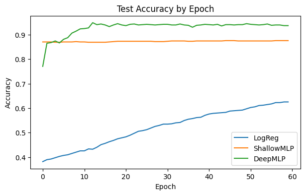

```python
plt.figure(figsize=(7,4))
for name, h in histories.items():
    plt.plot(h["test_acc"], label=name)
plt.title("Test Accuracy by Epoch")
plt.xlabel("Epoch")
plt.ylabel("Accuracy")
plt.legend()
plt.show()
```

### 5.2 Decision Boundaries

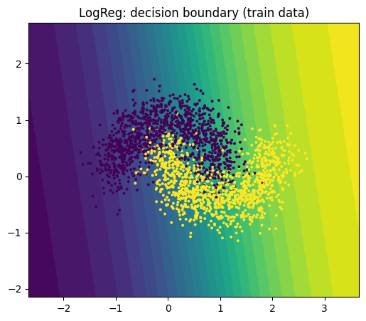

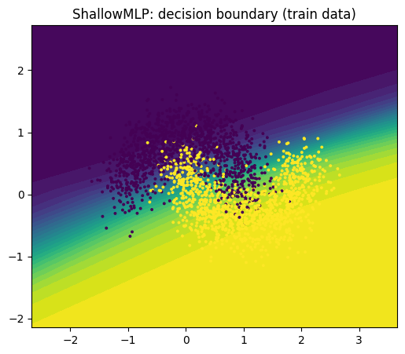

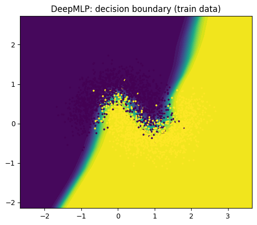

```python
def torch_predict_proba(model, scaler):
    def fn(grid_raw):
        grid_s = scaler.transform(grid_raw).astype(np.float32)
        with torch.no_grad():
            logits = model(torch.tensor(grid_s))
            probs = torch.sigmoid(logits).cpu().numpy()
        return probs
    return fn

for name, model in models.items():
    plot_decision_boundary(
        torch_predict_proba(model, scaler),
        X_train, y_train,
        title=f"{name}: decision boundary (train data)"
    )
```

### 5.4 Results

```python
# Build summary table with model capacity and performance
summary = {}

for name, h in histories.items():
    model = models[name]
    n_params = sum(p.numel() for p in model.parameters())

    summary[name] = {
        "n_params": n_params,
        "best_test_acc": float(np.max(h["test_acc"])),
        "final_test_acc": float(h["test_acc"][-1]),
        "final_test_auc": float(h["test_auc"][-1]),
        "final_test_logloss": float(h["test_loss"][-1]),
    }

df_summary = (
    pd.DataFrame(summary)
      .T
      .round(4)
)

# Ensure parameter count is shown as integer
df_summary["n_params"] = df_summary["n_params"].astype(int)

df_summary
```

|  | n_params | best_test_acc | final_test_acc | final_test_auc | final_test_logloss |
| --- | --- | --- | --- | --- | --- |
| LogReg | 3 | 0.6253 | 0.6253 | 0.7694 | 0.5639 |
| ShallowMLP | 65 | 0.8760 | 0.8760 | 0.9483 | 0.2936 |
| DeepMLP | 12737 | 0.9493 | 0.9373 | 0.9851 | 0.1661 |

## 6. Conclusion

Results highlight how model capacity and representation power affect performance on non-linearly separable data.

The **deep neural network** delivers the strongest overall results. With multiple hidden layers, the model learns a more expressive and flexible representation, producing a smooth decision boundary that closely follows the underlying data manifold. This is reflected in the highest AUC, lowest log loss, and best peak accuracy among the three models. These gains come at the cost of a substantial increase in model capacity, as reflected in the number of trainable parameters, highlighting the trade-off between representational power and complexity.

At the same time, the learning curves reveal an important nuance: the deep model reaches its best test accuracy earlier than the final epoch, after which performance stabilizes or slightly declines. This behavior highlights the practical need for techniques such as early stopping or regularization when training deeper networks.

In summary:

```
•	Linear models struggle when the data is inherently non-linear.
•	Shallow networks offer a powerful and often sufficient upgrade.
•	Deep networks provide the greatest expressive power, but require more careful training discipline.
```

These results reinforce the central motivation for deep learning: depth enables models to learn hierarchical, non-linear representations that simpler models cannot capture, especially as data complexity increases.